# Autocorrelation and Partial Autocorrelation

Intuitively, in a $MA(q)$ process the ACF will be zero for lags greater than $q$ . Moreover, because $q \neq 0$, the ACF will not be zero at lag $q$ . Thus, the ACF provides a considerable amount of information about the order of the dependence when the process is a moving average process.

Consider an invertible $MA(1)$ model, $X_t = W_t + \theta W_{t-1}$

$$ \gamma_X(2) = cov(X_t, X_{t-2}) = cov(W_t + \theta W_{t-1}, W_{t-2} + \theta W_{t-3}) = 0 $$

If the process, however, is $ARMA$ or $AR$, the $ACF$ alone tells us little about the orders of dependence. Consider a causal $AR(1)$ model, $X_t = \phi X_{t−1} + W_t$ . Then,

$$ \gamma_X(2) = cov(X_t, X_{t-2}) = cov(\phi X_{t-1} + W_t, X_{t-2}) = cov(\phi^2 X_{t-2} + \phi W_{t-1} + W_t, X_{t-2}) = \phi^2 \gamma_X(0) $$

Hence, it is worthwhile pursuing a function that will behave like the $ACF$ of $MA$ models, but for $AR$ models, namely, the **partial autocorrelation function** ($PACF$).

Suppose we break the $AR(1)$ chain of dependence by removing (or partial out) the effect $X_{t-1}$. That is, we consider the correlation between $X_t - \phi X_{t-1}$ and $X_{t-2} - \phi X_{t-1}$, because it is the correlation between $X_t$ and $X_{t-2}$ with the linear dependence of each on $X_{t-1}$ removed.

In this way, we have broken the dependence chain between $X_t$ and $X_{t-2}$. In fact,

$$ cov(X_t - \phi X_{t-1}, X_{t-2} - \phi X_{t-1}) = cov(W_t, X_{t-2} − \phi X_{t-1} ) = 0. $$

Hence, the tool we need is partial autocorrelation, which is the correlation between $X_s$ and $X_t$ with the linear effect of everything "in the middle" removed.

## Partial Autocorrelation Function

The partial autocorrelation function ($PACF$) of a stationary process, $X_t$, denoted $\phi_{h h}$, for $h=1,2,\cdots$ is

$$ \phi_{11} = cov(X_{t+1}, X_t) = \rho(1) $$

and

$$ \phi_{h h} = cov(X_{t+h} - \hat{X}_{t+h}, X_t - \hat{X}_t), \:\:\: h \geq 2 $$

where

$$ \hat{X}_{t+h} = \beta_1 X_{t+h-1} + \beta_2 X_{t+h-2} + \cdots + \beta_{h-1} X_{t+1} $$

and

$$ \hat{X}_{t} = \beta_1 X_{t+1} + \beta_2 X_{t+2} + \cdots + \beta_{h-1} X_{t+h-1} $$

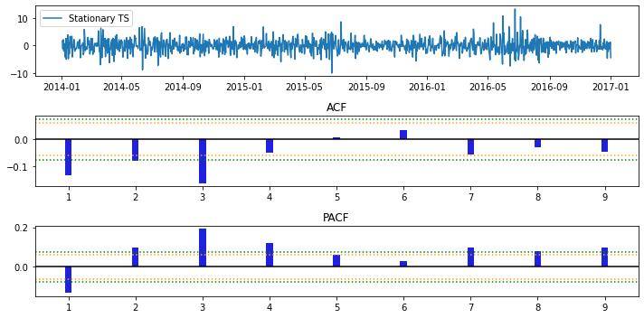

```python
figure
```

In general, the behavior of the $ACF$ and $PACF$ for $ARMA$ Models is

[output not shown]